# Colour volume estimation

Hugo Gruson

2020-12-09

Traditionally, colour volume or “colourfulness” of an object has been measured by computing the volume of the convex hull containing the data points, as described in (Stoddard and Prum 2008)

$\alpha$-shapes are a new tool available in `pavo` to estimate colour volumes, while allowing the presence of voids and pockets, which may lead to a more accurate measurement of “colourfulness” than convex hulls. For more information on the theoretical background, please report to the related article (Gruson 2020)

# $\alpha$-shapes in chromaticity diagrams

You can plot the colour volume using $\alpha$-shape with the `vol()` function (for non-interactive plots, `tcsvol()` otherwise) by specifying `type = "alpha"`. By default, this will use the $\alpha^*$ value defined in Gruson (2020).

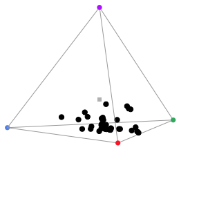

```r
library(pavo)
data(flowers)
vis_flowers <- vismodel(flowers, visual = "avg.uv")
tcs_flowers <- colspace(vis_flowers)
plot(tcs_flowers)
```

```r
vol(tcs_flowers, type = "alpha")
```

```
#> 'avalue' automatically set to 1.8275e-01
```

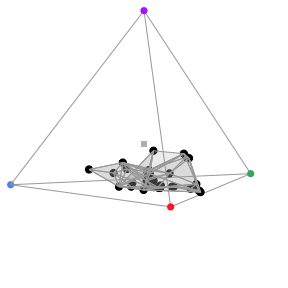

To get the colour volume value, you can use the `summary.colspace()` function. The colour volume computed by the convex hull is contained in the `c.vol` column and the colour volume computed by the $\alpha$-shape (with parameter $\alpha^*$) is contained in the `a.vol` column:

```r
summary(tcs_flowers)
```

```
#> Colorspace & visual model options:
#>  * Colorspace: tcs
#>  * Quantal catch: Qi
#>  * Visual system, chromatic: avg.uv
#>  * Visual system, achromatic: none
#>  * Illuminant: ideal, scale = 1 (von Kries colour correction not applied)
#>  * Background: ideal
#>  * Relative: TRUE
#>  * Max possible chromatic volume: 0.215735
#> 'avalue' automatically set to 1.8275e-01
#>            centroid.u centroid.s centroid.m centroid.l      c.vol  rel.c.vol
#> all.points 0.06025649  0.2375617   0.317973  0.3842088 0.01432726 0.06617479
#>            colspan.m  colspan.v huedisp.m huedisp.v   mean.ra   max.ra
#> all.points 0.2000963 0.01309332 0.7414951 0.2235526 0.8319508 0.999151
#>                  a.vol
#> all.points 0.006057976
```

Alternatively, you can set the $\alpha$ parameter to the value of your choice via the `avalue` argument:

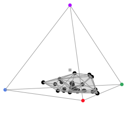

```r
plot(tcs_flowers)
vol(tcs_flowers, type = "alpha", avalue = 0.5)
```

# $\alpha$-shapes in perceptually uniform spaces

In the previous section, we focused on $\alpha$-shapes in chromaticity diagrams since it is the most common space where convex hulls (that $\alpha$-shapes aim at replacing) are used. But it is also possible to use $\alpha$-shapes in other spaces, such as perceptually uniform spaces.

Let’s first build this uniform space and look at the data points in this space:

```r
cd_flowers <- coldist(vis_flowers)
```

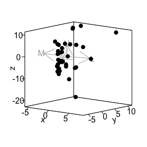

```r
xy_flowers <- jnd2xyz(cd_flowers)
plot(xy_flowers)
```

High-level functions to build the $\alpha$-shape directly in `pavo` have not yet been implemented but you can use the `alphashape3d` package directly to compute the $\alpha$-shapes, its volume and display it in a 3D interactive plot.

```r
library(alphashape3d)
ashape_jnd <- ashape3d(as.matrix(xy_flowers), alpha = 10)
volume_ashape3d(ashape_jnd)
```

```
#> [1] 748.863
```

```r
plot(ashape_jnd)
```

```
#> Device  1  : alpha =  10
#> Warning in rgl.material(...): partial argument match of 'col' to 'color'
```

[interactive chart not shown]

# Colour volume overlap with $\alpha$-shapes

```r
data(sicalis)
tcs.sicalis.C <- subset(colspace(vismodel(sicalis)), "C")
tcs.sicalis.B <- subset(colspace(vismodel(sicalis)), "B")
```

```r
voloverlap(tcs.sicalis.C, tcs.sicalis.B, type = "alpha", plot = TRUE)
```

```
#> 'avalue' automatically set to 2.4445e-02
#> 'avalue' automatically set to 2.6255e-01
#> Warning in overlap3d(colsp1, colsp2, avalue, plot, interactive, col, fill, :
#> interactive = FALSE has not been implemented yet, falling back to interactive
#> plot.
#> Warning in f(...): partial argument match of 'col' to 'color'
```

[interactive chart not shown]

Gruson, Hugo. 2020. “Estimation of Colour Volumes as Concave Hypervolumes Using α-Shapes.” *Methods in Ecology and Evolution* 11 (8): 955–63. https://doi.org/10.1111/2041-210X.13398.

Stoddard, Mary Caswell, and Richard O. Prum. 2008. “Evolution of Avian Plumage Color in a Tetrahedral Color Space: A Phylogenetic Analysis of New World Buntings.” *The American Naturalist* 171 (6): 755–76. https://doi.org/10.1086/587526.